# Logistic Regression - Nuclear Weapons States

Ryan McClarren

February 24, 2016

```r
library(dplyr)
library(ggplot2)
library(reshape2)
```

First we load in the dataset concerning the presence of a nuclear weapons program in a given country. The data includes a binary variable for whether or not the country has a program, economic variables, geopolitical variables etc. The data set originally came from [here](http://pages.ucsd.edu/~egartzke/htmlpages/data.html), though the Rdata version of it was produced by me. The data set was used in the following paper:

> Jo, Dong-Joon, and Erik Gartzke. 2007. Determinants of Nuclear Weapons Proliferation: A Quantitative Model. The Journal of Conflict Resolution 51(1):167-194.

```r
load("nucweap.RData")
head(nw)
```

```
## Source: local data frame [6 x 20]
##
##   ccode1  year nuk_a_p nuk_apl nuke_df nuke_dfl nuk7set1     new_econ
##    (int) (int)   (int)   (int)   (int)    (int)    (int)        (dbl)
## 1    230  1939       0       0       0        0        4 4.975331e-03
## 2    790  1939       0       0       0        0        0           NA
## 3     94  1939       0       0       0        0        0 2.817101e-05
## 4    678  1939       0       0       0        0        0           NA
## 5    145  1939       0       0       0        0        0 4.265896e-05
## 6    367  1939       0       0       0        0        1 2.343610e-04
## Variables not shown: l_year_t (dbl), ln_ri_t (dbl), r_nukep (int), r_nukeb
##   (int), nuke_a_d (int), d_isol (dbl), ln_xst1 (dbl), democ (int),
##   npt_rati (int), npt_eff (dbl), majpow (int), regpowt (int)
```

# Logistic Regression: Predicting a Binary Outcome

In this lecture we will be interested in predicting whether a nation has a nuclear weapons program in a given year. This variable will be 0 or 1, so we would like our regression model to give a prediction in this range so that we can interpret the output as a probability. Unfortunately, a standard linear regression model can give an output of any real number. Therefore, we would like a model that has its output restricted to the range 0 to 1. To do this we will construct a model that predicts a real number and then map that number to the range 0 to 1. Specifically, the model will have the form

$$\eta = \alpha_0 + \alpha_1 x_1 + \alpha_2 x_2 + \dots \alpha_n x_n.$$
Then this output will be mapped to the range $[0,1]$ using the inverse logit function. The logit function is given by
$$\mathrm{logit}\left(p\right) = \log\left(\frac{p}{1-p}\right) \equiv \eta.$$
Therefore, we can find the value of the probability as a function of the $\mathbf{x}$ variables by using the inverse of the logit function
$$p(\mathbf{x}) = \mathrm{logit}^{-1} (\eta) = \frac{e^\eta}{e^\eta+1}.$$
Often, $\eta$ is called the logarithm of the odds, or more commonly log odds. This is because the odds of an outcome are given by the fraction $p/(1-p)$, that is the ratio of the probability of success to the probability failure.

We call such a model a logit model because we are predicting the logit of the probability. The estimation of the coefficients $\alpha_i$ is done differently than for a standard linear model. For a description of how this is done, see this lecture. The basic idea is that we consider the outcome is a binomial random variable with probability of success given by $p = \mathrm{logit}^{-1}(\eta)$. By maximizing the binomial likelihood over the parameters $\alpha_i$, one fits the model.

# Our first logit model

We want to see if the likelihood of having a nuclear weapons program in a given year is likely based on whether a state had a program in the previous year. We can look at this using a probability table.

```r
with(nw,table(nuk_apl,nuk_a_p))
```

```
##        nuk_a_p
## nuk_apl    0    1
##       0 5826   13
##       1   24  464
```

This is a bit ugly, so let’s rename the variables

```r
nw_rename <- rename(nw, NW.Program = nuk_a_p, NW.Program.Prev.Year = nuk_apl)
with(nw_rename,table(NW.Program.Prev.Year,NW.Program))
```

```
##                     NW.Program
## NW.Program.Prev.Year    0    1
##                    0 5826   13
##                    1   24  464
```

We can now make a model that attempts to predict whether a state will have a NW program in a given year based solely on whether it had one in the previous year:

```r
summary(simp.model <- glm(NW.Program ~ NW.Program.Prev.Year, data = nw_rename, family = binomial(link = "logit")))
```

```
##
## Call:
## glm(formula = NW.Program ~ NW.Program.Prev.Year, family = binomial(link = "logit"),
##     data = nw_rename)
##
## Deviance Residuals:
##     Min       1Q   Median       3Q      Max
## -2.4545  -0.0668  -0.0668  -0.0668   3.4950
##
## Coefficients:
##                      Estimate Std. Error z value Pr(>|z|)
## (Intercept)           -6.1051     0.2777  -21.99   <2e-16 ***
## NW.Program.Prev.Year   9.0670     0.3477   26.07   <2e-16 ***
## ---
## Signif. codes:  0 '***' 0.001 '**' 0.01 '*' 0.05 '.' 0.1 ' ' 1
##
## (Dispersion parameter for binomial family taken to be 1)
##
##     Null deviance: 3383.25  on 6326  degrees of freedom
## Residual deviance:  376.15  on 6325  degrees of freedom
## AIC: 380.15
##
## Number of Fisher Scoring iterations: 9
```

From this result we can see that the presence of program in the previous year is a significant predictor based on the significance of the coefficient.

I will define an inverse logit function for convenience

```r
invlogit <- function(x) exp(x)/(1+exp(x))
```

Let’s look at the probability of developing a nuclear weapons program for a country that does not have a program. In this example this quantity is related to the intercept because the value of `NW.Program.Prev.Year` is zero for a country that did not have a program in the previous year:

$$\log \left(\frac{p}{1-p}\right) = -6.1051366$$
$$\frac{p}{1-p} = \exp(-6.1051366) = 0.0022314$$
$$p = \mathrm{logit}^{-1} (-6.1051366) = 0.0022264$$
This means that there is a 0.22% chance of a state that did not have a NW program the year before developing a program.

We could also look at the probability that a country that has a program the previous year keeping it:

$$\log \left(\frac{p}{1-p}\right) = -6.1051366 + 9.0669673= 2.9618307$$
$$\frac{p}{1-p} = \exp(2.9618307) = 19.3333333$$
$$p = \mathrm{logit}^{-1} (2.9618307) = 0.9508197$$

# More Complicated Models

We can add another predictor to the model. In particular we will add the indicator variable for whether or not the country has a rival with nuclear weapons.

```r
nw_rename <- rename(nw_rename, Rival.NW = r_nukep)
summary(model2 <- glm(NW.Program ~ NW.Program.Prev.Year + Rival.NW, data = nw_rename, family = binomial(link = "logit")))
```

```
##
## Call:
## glm(formula = NW.Program ~ NW.Program.Prev.Year + Rival.NW, family = binomial(link = "logit"),
##     data = nw_rename)
##
## Deviance Residuals:
##     Min       1Q   Median       3Q      Max
## -2.8405  -0.0624  -0.0624  -0.0624   3.5333
##
## Coefficients:
##                      Estimate Std. Error z value Pr(>|z|)
## (Intercept)           -6.2401     0.2868 -21.761  < 2e-16 ***
## NW.Program.Prev.Year   8.7172     0.3492  24.966  < 2e-16 ***
## Rival.NW               1.5391     0.4456   3.454 0.000553 ***
## ---
## Signif. codes:  0 '***' 0.001 '**' 0.01 '*' 0.05 '.' 0.1 ' ' 1
##
## (Dispersion parameter for binomial family taken to be 1)
##
##     Null deviance: 3383.25  on 6326  degrees of freedom
## Residual deviance:  363.04  on 6324  degrees of freedom
## AIC: 369.04
##
## Number of Fisher Scoring iterations: 9
```

$$\log \left(\frac{p_\mathrm{no\, rival}}{1-p_\mathrm{no\, rival}}\right) = -6.2400569$$
$$\frac{p_\mathrm{no\, rival}}{1-p_\mathrm{no\, rival}} = \exp(-6.2400569) = 0.0019497$$
$$p_\mathrm{no\, rival} = \mathrm{logit}^{-1} (-6.2400569) = 0.001946$$

If the country HAS a rival with a NW program then the probability is

$$\log \left(\frac{p_\mathrm{rival}}{1-p_\mathrm{rival}}\right) = -6.2400569 + 1.5390772 = -4.7009797$$
$$\frac{p_\mathrm{rival}}{1-p_\mathrm{rival}} = \exp(-4.7009797) = 0.0090864$$
$$p_\mathrm{rival} = \mathrm{logit}^{-1} (-4.7009797) = 0.0090046$$

Therefore, the increase in the probability is $p_\mathrm{rival} - p_\mathrm{no\, rival} = 0.0070586$.

For the next model we will add a continuous variable: the logarithm of the number of years since 1938.

```r
nw_rename <- mutate(nw_rename, Year = as.integer(exp(l_year_t) + 1938))
summary(model3 <- glm(NW.Program ~ NW.Program.Prev.Year + Rival.NW + l_year_t, data = nw_rename, family = binomial(link = "logit")))
```

```
##
## Call:
## glm(formula = NW.Program ~ NW.Program.Prev.Year + Rival.NW +
##     l_year_t, family = binomial(link = "logit"), data = nw_rename)
##
## Deviance Residuals:
##     Min       1Q   Median       3Q      Max
## -3.0475  -0.0730  -0.0624  -0.0463   3.6103
##
## Coefficients:
##                      Estimate Std. Error z value Pr(>|z|)
## (Intercept)           -9.8754     1.0226  -9.657  < 2e-16 ***
## NW.Program.Prev.Year   8.9650     0.3794  23.630  < 2e-16 ***
## Rival.NW               1.5966     0.4442   3.594 0.000325 ***
## l_year_t               1.0311     0.2689   3.835 0.000125 ***
## ---
## Signif. codes:  0 '***' 0.001 '**' 0.01 '*' 0.05 '.' 0.1 ' ' 1
##
## (Dispersion parameter for binomial family taken to be 1)
##
##     Null deviance: 3383.25  on 6326  degrees of freedom
## Residual deviance:  348.84  on 6323  degrees of freedom
## AIC: 356.84
##
## Number of Fisher Scoring iterations: 9
```

This model tells us that as time has marched on, the likelihood of a state developing nuclear weapons increases. When we use a continuous variable in a logistic model, it can be useful to plot the effect of the variable in a chart of the following form.

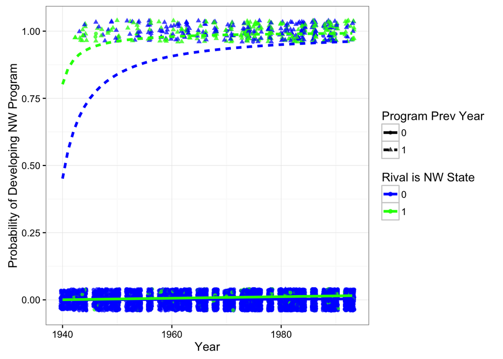

```r
pred_vals <- data_frame(Year = rep(seq(1940,1993),4),
                        Rival.NW = c(rep(0,(1994-1940)*2),rep(1,(1994-1940)*2)),
                        NW.Program.Prev.Year = c(rep(0,(1994-1940)),rep(1,(1994-1940)),
                                                 rep(1,(1994-1940)),rep(0,(1994-1940))))
pred_vals <- mutate(pred_vals, l_year_t = log(Year-1938))
pred_vals <- mutate(pred_vals,NW.Program = predict(model3, pred_vals, type='response'))
ggplot(nw_rename, aes(x = Year, y = NW.Program, color = as.factor(Rival.NW), shape = as.factor(NW.Program.Prev.Year))) + geom_jitter(width = 0.99, height = 0.1,alpha = 0.75) + geom_line(data=pred_vals, aes(linetype = as.factor(NW.Program.Prev.Year)), size = 1.25) + scale_color_manual("Rival is NW State", values = c("0" = "blue", "1"="green") ) + scale_shape_discrete("Program Prev Year") + scale_linetype_discrete("Program Prev Year")  + theme_bw() + scale_y_continuous("Probability of Developing NW Program")
```

Notice that the impact of year is nonlinear: it has an larger impact early on than later. This is due to both the logarithmic transform of the the year and the logistic map.

Something we would want to test is the false positive and false negative rates for our model. Ideally, we would do this using an in and out of sample test. That is, we would build the model on some fraction of the data and test it on the other portion. We will do this later, but first we will use all the data to build and test the model. As we will see it is important to set the threshold for the prediction to say that country will develop a program in a given year. The simplest threshold would be 50% so that the model says the country is more likely than not to develop a program. We could increase that threshold to be more conservative so that we only say a country will develop a program when the model is more certain. One the other hand, we could lower the threshold if we want to identify countries that are potentially likely to develop a program. There will be tradeoffs in these approaches as we will see.

```r
nw_predict <- mutate(nw_rename, Pred = predict(model3, nw_rename, type = "response"))
yes_no <- function(x,level) 1*(x>level)
nw_predict <- mutate(nw_predict, Level50 = yes_no(Pred,0.5))
level50 <- group_by(nw_predict, Level50, NW.Program) %>% summarise(number=n())
print(level50)
```

```
## Source: local data frame [4 x 3]
## Groups: Level50 [?]
##
##   Level50 NW.Program number
##     (dbl)      (int)  (int)
## 1       0          0   5826
## 2       0          1     13
## 3       1          0     24
## 4       1          1    464
```

When we use 50% as the threshold we have a false positive rate (that is how often we say that a state will have a program when actually it didn’t) of

$$\frac{24}{464 + 24} = 0.0491803$$

The false negative rate is the fraction of times where the model says a country will not have a program when it does develop one. This number is

$$\frac{13}{13 + 5826} = 0.0022264$$

To decrease the false positive rate we could increase the threshold from 50% to, for example, 90%. Here are the results for making this change:

```r
nw_predict <- mutate(nw_predict, Level90 = yes_no(Pred,0.9))
level90 <- group_by(nw_predict, Level90, NW.Program) %>% summarise(number=n())
print(level90)
```

```
## Source: local data frame [4 x 3]
## Groups: Level90 [?]
##
##   Level90 NW.Program number
##     (dbl)      (int)  (int)
## 1       0          0   5834
## 2       0          1     55
## 3       1          0     16
## 4       1          1    422
```

This makes the false positive rate drop to 0.0365297 based on the calculation:

$$\frac{16}{422 + 16} = 0.0365297$$

The flip-side is, however, that the false negative rate goes up to 0.0093394 based on the calculation:

$$\frac{55}{55 + 5834} = 0.0093394$$

Finally, if we lower our threshold we effectively say that we are sensitive to a nation developing a program, we will increase our false positive rate and drop our false negative rate. If we set the threshold to 1.5% (that is, if there is a 1.5% chance of a country developing a program in a given year we call that a “yes”), the false positive rate should jump.

```r
nw_predict <- mutate(nw_predict, Level15 = yes_no(Pred,0.015))
level15 <- group_by(nw_predict, Level15, NW.Program) %>% summarise(number=n())
print(level15)
```

```
## Source: local data frame [4 x 3]
## Groups: Level15 [?]
##
##   Level15 NW.Program number
##     (dbl)      (int)  (int)
## 1       0          0   5816
## 2       0          1     13
## 3       1          0     34
## 4       1          1    464
```

This makes the false positive rate increase to 0.0682731 based on the calculation:

$$\frac{34}{464 + 34} = 0.0682731$$

Now the false negative rate goes down to 0.0022302 based on the calculation:

$$\frac{13}{13 + 5816} = 0.0022302$$

With a classification model the upshot is that the user has to specify which is worse a false positive or a false negative, and adjust the use of the model accordingly.

# Predicting Development of a Program

One way to use such a model would be to predict if a country will develop a program in the next year. You could use this data to try and head off such a program (or I suppose to have a pre-emptive strike). To show how well this model would do we will make a prediction for year $n$ using only the data up through year $n-1$. To do this we also will not try to predict any countries abandoning a program, only countries that develop one.

First, let’s define an R function that predicts the number of new NW states in a given year given previous years of data.

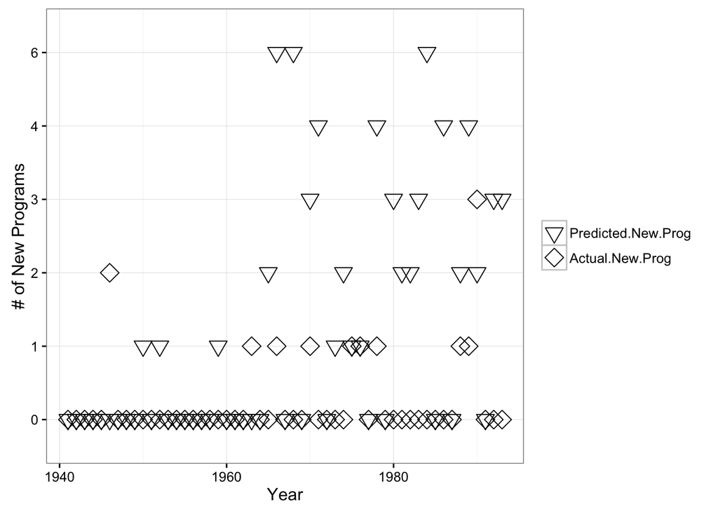

```r
predict_year = function(dta, year_consider, threshold = 0.5){
  build_dta <- filter(dta, Year < year_consider, NW.Program.Prev.Year == 0)
  test_dta <- filter(dta, Year==year_consider, NW.Program.Prev.Year == 0)
  result= c(0,sum(test_dta$NW.Program))
  if (nrow(test_dta) > 0) {
  year_model <- glm(NW.Program ~ Rival.NW  + majpow + nuk7set1 + l_year_t, data = build_dta, family = binomial(link = "logit"))
  preds <- predict(year_model, test_dta, type = "response")
  result[[1]] = sum( 1.0*(preds > threshold))
  }
  result
}
results <- data_frame(year = seq(1941,1993))
results <- mutate(results, Predicted.New.Prog = -1, Actual.New.Prog = 0)
count = 1
for (i in results$year) {
  results[count,2:3] <- predict_year(nw_rename, i, 0.03)
  count <- count + 1
}
meltDF <- melt(results, id="year")
ggplot(meltDF, aes(x=year, y = as.factor(value), shape = variable)) + geom_point(size = 4, fill="black") + scale_x_continuous("Year") + scale_y_discrete("# of New Programs") + scale_shape_manual("", values = c(6,5)) + theme_bw()
```

Unfortunately, this model is not great. It does predict some years perfectly (for example, 1975 and 1976), though for many other years it over predicts the number of new programs. Also, to get these results we had to set the prediction threshold to be very low.